### Overview

1. Voting behavior is a hard problem is because choosing the US president is a national problem , but also involves at state level. So both the national and state level need to be taken into account.
2. Nate Silver looked at the full range of probability so for each state he could calculated the probability of support and use the following day polling data to support his model.
3. Every poll has error such as the nonresponse bias, and it has systematic error, and they often miss in the same direction.

### Election Data

4. The Dimension of `election.raw` after remove rows with `fip` = 2000 is 18345 observations of 5 variables. The reason we remove these observations is that they are replications of the observations of `fip` = AK.

### Data Wrangling

5. After we split the data into `election_federal`, `election_state` and `election_county`. We report they have dimensions of 32, 302 and 18011 observations respectively.
6. Using the data set `election_federal` we can report that there are 32 candidates, and the bar chart of all candidates against the log of the number of the votes is shown below.

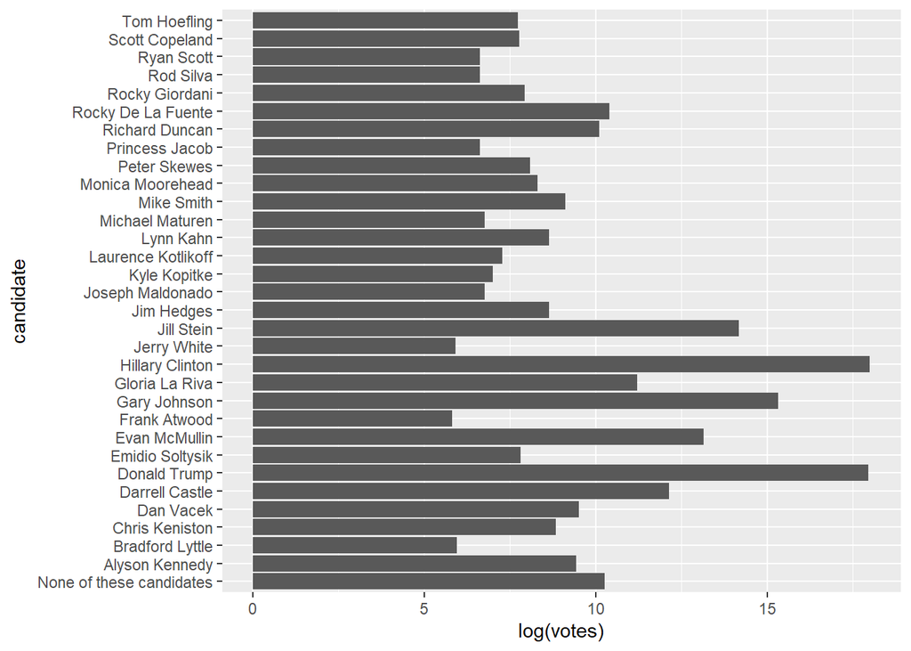

7. First few rows of `county_winner` and `state_winner` are shown below

| county | fips | candidate | state | votes | total | pct |
| --- | --- | --- | --- | --- | --- | --- |
| Los Angeles County | 6037 | Hillary Clinton | CA | 2464364 | 3421533 | 0.7202514 |
| Cook County | 17031 | Hillary Clinton | IL | 1611946 | 2156395 | 0.7475189 |
| Maricopa County | 4013 | Donald Trump | AZ | 747361 | 1536743 | 0.4863279 |
| Harris County | 48201 | Hillary Clinton | TX | 707914 | 1305434 | 0.5422825 |
| San Diego County | 6073 | Hillary Clinton | CA | 735476 | 1291078 | 0.5696604 |
| Orange County | 6059 | Hillary Clinton | CA | 609961 | 1186203 | 0.5142130 |

| county | fips | candidate | state | votes | total | pct |
| --- | --- | --- | --- | --- | --- | --- |
| NA | CA | Hillary Clinton | CA | 8753788 | 14060856 | 0.6225644 |
| NA | FL | Donald Trump | FL | 4617886 | 9419886 | 0.4902274 |
| NA | TX | Donald Trump | TX | 4685047 | 8917965 | 0.5253493 |
| NA | NY | Hillary Clinton | NY | 4556124 | 7660190 | 0.5947795 |
| NA | PA | Donald Trump | PA | 2970733 | 6115402 | 0.4857789 |
| NA | IL | Hillary Clinton | IL | 3090729 | 5523142 | 0.5595962 |